# Exploration Diamonds Data Set

Finn Burgemeister und Tobias Machnitzki

# 1.

First we want to load the data and get an overview of what we are dealing with.

```r
library(ggplot2)
library(scales)
library(dplyr)
library(knitr)
library(markdown)
data(diamonds)
summary(diamonds)
```

```
     carat               cut        color        clarity          depth           table           price
 Min.   :0.2000   Fair     : 1610   D: 6775   SI1    :13065   Min.   :43.00   Min.   :43.00   Min.   :  326
 1st Qu.:0.4000   Good     : 4906   E: 9797   VS2    :12258   1st Qu.:61.00   1st Qu.:56.00   1st Qu.:  950
 Median :0.7000   Very Good:12082   F: 9542   SI2    : 9194   Median :61.80   Median :57.00   Median : 2401
 Mean   :0.7979   Premium  :13791   G:11292   VS1    : 8171   Mean   :61.75   Mean   :57.46   Mean   : 3933
 3rd Qu.:1.0400   Ideal    :21551   H: 8304   VVS2   : 5066   3rd Qu.:62.50   3rd Qu.:59.00   3rd Qu.: 5324
 Max.   :5.0100                     I: 5422   VVS1   : 3655   Max.   :79.00   Max.   :95.00   Max.   :18823
                                    J: 2808   (Other): 2531
       x                y                z
 Min.   : 0.000   Min.   : 0.000   Min.   : 0.000
 1st Qu.: 4.710   1st Qu.: 4.720   1st Qu.: 2.910
 Median : 5.700   Median : 5.710   Median : 3.530
 Mean   : 5.731   Mean   : 5.735   Mean   : 3.539
 3rd Qu.: 6.540   3rd Qu.: 6.540   3rd Qu.: 4.040
 Max.   :10.740   Max.   :58.900   Max.   :31.800
```

The first thing we notice is that cut, color and clarity do not contain numbers for evaluation, but some kind of tags. So lets look at some combinations:

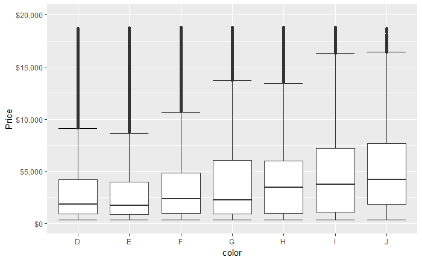

```r
ggplot(diamonds, aes(x = color, y = price)) +
  stat_boxplot(geom="errorbar") +
  geom_boxplot() +
  coord_cartesian(ylim=c(0, 20000)) +
  scale_y_continuous(labels=dollar) +
  xlab("color") + ylab("Price")
```

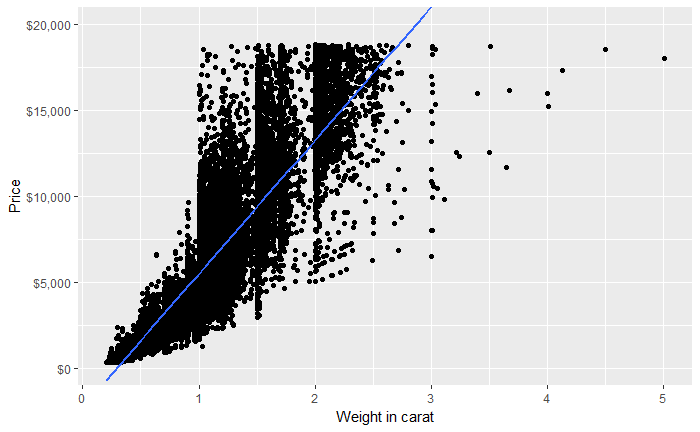

```r
ggplot(diamonds, aes(x = carat, y = price)) +
  geom_point() +
  geom_smooth(method=lm,   # Add linear regression line
                se=FALSE) +   # Don't add shaded confidence region
  scale_y_continuous(labels=dollar) +
  coord_cartesian(ylim=c(0, 20000)) +
  xlab("Weight in carat") + ylab("Price")
```

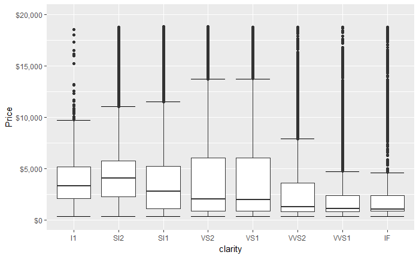

```r
ggplot(diamonds, aes(x = clarity, y = price)) +
  stat_boxplot(geom="errorbar") +
  geom_boxplot() +
  coord_cartesian(ylim=c(0, 20000)) +
  scale_y_continuous(labels=dollar) +
  xlab("clarity") + ylab("Price")
```

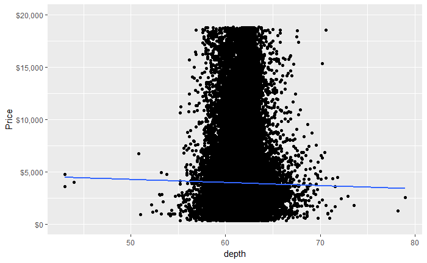

```r
ggplot(diamonds, aes(x = depth, y = price)) +
  geom_point() +
  geom_smooth(method=lm,   # Add linear regression line
                se=FALSE) +   # Don't add shaded confidence region
  scale_y_continuous(labels=dollar) +
  coord_cartesian(ylim=c(0, 20000)) +
  xlab("depth") + ylab("Price")
```

# 2.

Furthermore we want to know, how the Price correlates with the cut.

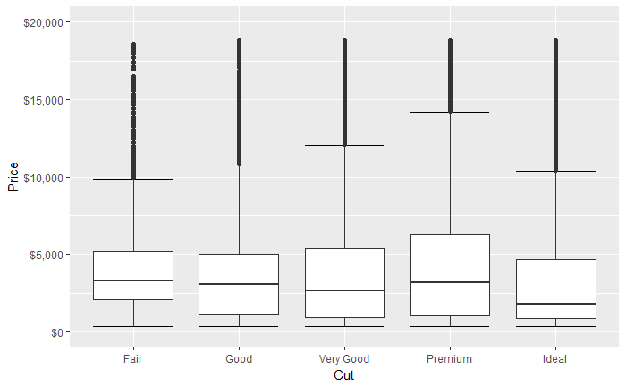

```r
ggplot(diamonds, aes(x = cut, y = price)) +
  stat_boxplot(geom="errorbar") +
  geom_boxplot() +
  coord_cartesian(ylim=c(0, 20000)) +
  scale_y_continuous(labels=dollar) +
  xlab("Cut") + ylab("Price")
```

This shows quite easaly, that the Premium cut in average has a much higher price than an ideal cutted diamond.

Lets have a look at some numbers:

```r
diamonds %>%
  group_by(cut) %>%
  summarise(max_price = max(price),
            min_price = min(price),
            median_price = median(price))
```

| cut | max_price | min_price | median_price |
| --- | --- | --- | --- |
| Fair | 18574 | 337 | 3282.0 |
| Good | 18788 | 327 | 3050.5 |
| Very Good | 18818 | 336 | 2648.0 |
| Premium | 18823 | 326 | 3185.0 |
| Ideal | 18806 | 326 | 1810.0 |

The maximum price of each cut category is very similar,as well as the minimum price. This is due to the fact, that we look at comlete diamonds here, which price depends most on size. So even if the cut is ideal, if it is a very small diamond it still will be cheap. To see the real effect of the shape on the price we need to use a new category: price/carat.

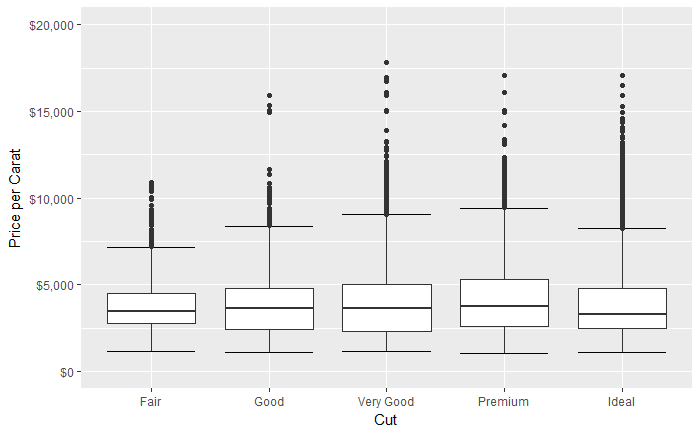

```r
ggplot(diamonds, aes(x = cut, y = price/carat)) +
  stat_boxplot(geom="errorbar") +
  geom_boxplot() +
  coord_cartesian(ylim=c(0, 20000)) +
  scale_y_continuous(labels=dollar) +
  xlab("Cut") + ylab("Price per Carat")
```

```r
diamonds %>%
  group_by(cut) %>%
  summarise(max_price_per_carat = max(price/carat),
            min_price_per_carat = min(price/carat),
            median_price_per_carat = median(price/carat))
```

| cut | max_price_per_carat | min_price_per_carat | median_price_per_carat |
| --- | --- | --- | --- |
| Fair | 10909.33 | 1168.000 | 3449.444 |
| Good | 15928.00 | 1080.645 | 3613.250 |
| Very Good | 17828.85 | 1138.710 | 3605.826 |
| Premium | 17083.18 | 1051.163 | 3763.333 |
| Ideal | 17077.67 | 1109.091 | 3307.143 |

Now we can see, that a fair cut drives down the maximum price you can get, but better than very good does not really makes a huge difference on th price. In fact the Very Good cut category has not only the highest priced diamond, but as well higher median, than the Ideal cutted diamonds.